# Supervised GMM vs. EM vs. CEM

This notebook compares three ways of fitting a `GaussianMixture` on the same synthetic data:

- **EM**: standard soft-assignment fitting, no label information.
- **CEM**: Classification EM — hard assignment via `argmax(resp)` each iteration, no label information.
- **Supervised**: `fit(X, labels=y)` — the assignment comes from the true label instead of `argmax(resp)`, converging in a single M-step (see the "Supervised Fitting" section of the user guide, and `docs/superpowers/specs/2026-08-10-supervised-gmm-design.md` for the literature this is grounded in: Celeux & Govaert 1992, McLachlan & Peel 2000, Fraley & Raftery 2002).

The data reuses 3 of the 4 Gaussian components from `notebooks/gmm.ipynb` (same centers/covariances/sample counts), reduced to 3 classes so the comparison lines up directly with 3-way supervised labels.

```python
import torch
import numpy as np
import matplotlib.pyplot as plt
import time

import os
os.chdir('../')

import tgmm
import importlib
importlib.reload(tgmm)

from tgmm import (
    GaussianMixture, plot_gmm, dynamic_figsize, generate_gmm_data,
    match_predicted_to_true_labels, ClusteringMetrics,
)

device = 'cuda' if torch.cuda.is_available() else 'cpu'
random_state = 42
np.random.seed(random_state)
torch.manual_seed(random_state)
print('Using device:', device)
```

```
Using device: cpu
```

## Data: 3 of the 4 Gaussians from `gmm.ipynb`

Same centers/covariances/sample counts as `notebooks/gmm.ipynb`, dropping the `(2, -2)` component and keeping the other three (spherical, diagonal, and full covariance, moderately overlapping).

```python
centers = [np.array([0, 2]), np.array([0, 0]), np.array([2, 2])]
covs = [
    1.0 * np.eye(2),                    # spherical covariance
    np.array([[2, 0], [0, 0.5]]),       # diagonal covariance
    np.array([[0.2, 0.5], [0.5, 2]]),   # full covariance
]
n_samples = [800, 1000, 1000]
legend_labels = [f'Class {i}' for i in range(len(n_samples))]

X_tensor, y_tensor = generate_gmm_data(centers, covs, n_samples, device=device, random_state=random_state)
X = X_tensor.cpu().numpy()
y_true = y_tensor.cpu().numpy()
n_components = len(n_samples)

plot_gmm(X=X, true_labels=y_true, title='True Classes', legend_labels=legend_labels,
         show_ellipses=False, show_means=False)
plt.show()
```

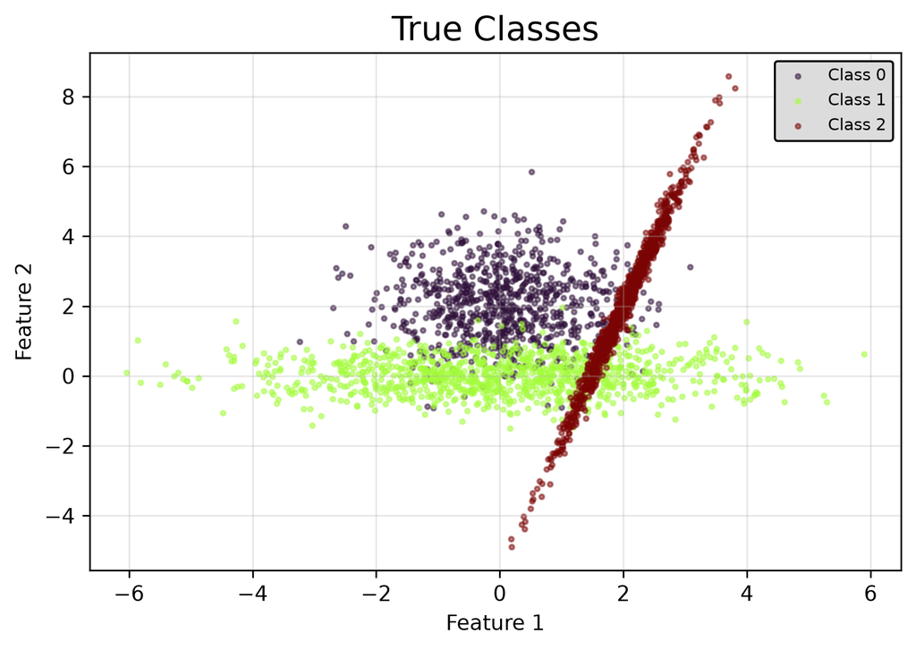

## Fitting all three models

EM and CEM don't see `y_tensor` at all; only the supervised fit does.

```python
gmm_em = GaussianMixture(n_components=n_components, init_means='random', n_init=10, random_state=random_state)
t0 = time.time()
gmm_em.fit(X_tensor)
time_em = time.time() - t0

gmm_cem = GaussianMixture(n_components=n_components, init_means='random', n_init=10, random_state=random_state, cem=True)
t0 = time.time()
gmm_cem.fit(X_tensor)
time_cem = time.time() - t0

gmm_sup = GaussianMixture(n_components=n_components)
t0 = time.time()
gmm_sup.fit(X_tensor, labels=y_tensor)
time_sup = time.time() - t0

print(f"EM:         iters={gmm_em.n_iter_:4d}  converged={gmm_em.converged_}  time={time_em:.4f}s  mean log-lik={gmm_em.score(X_tensor):.4f}")
print(f"CEM:        iters={gmm_cem.n_iter_:4d}  converged={gmm_cem.converged_}  time={time_cem:.4f}s  mean log-lik={gmm_cem.score(X_tensor):.4f}")
print(f"Supervised: iters={gmm_sup.n_iter_:4d}  converged={gmm_sup.converged_}  time={time_sup:.4f}s  mean log-lik={gmm_sup.score(X_tensor):.4f}")
print(f"\nSupervised gmm.classes_: {gmm_sup.classes_.cpu().tolist()}")
```

```
EM:         iters=  53  converged=True  time=0.3978s  mean log-lik=-3.0506
CEM:        iters=  15  converged=True  time=0.2053s  mean log-lik=-3.0587
Supervised: iters=   1  converged=True  time=0.0014s  mean log-lik=-3.0517

Supervised gmm.classes_: [0, 1, 2]
```

## Visual comparison

EM/CEM cluster indices are arbitrary, so they're remapped to the true labels via the Hungarian algorithm (`match_predicted_to_true_labels`) purely for coloring — the supervised fit needs no remapping since its component index already *is* the label (`classes_ == [0, 1, 2]`).

```python
pred_em = match_predicted_to_true_labels(y_tensor, gmm_em.predict(X_tensor))
pred_cem = match_predicted_to_true_labels(y_tensor, gmm_cem.predict(X_tensor))
pred_sup = gmm_sup.predict(X_tensor)

figsize = dynamic_figsize(1, 4)
fig, axes = plt.subplots(1, 4, figsize=figsize)
fig.suptitle('True labels vs. EM vs. CEM vs. Supervised')

plot_gmm(X=X, true_labels=y_true, ax=axes[0], title='True Classes',
         show_ellipses=False, show_means=False)
plot_gmm(X=X, gmm=gmm_em, ax=axes[1], title=f'EM\n({gmm_em.n_iter_} iters)',
         color_by_cluster=True, match_labels_to_true=True, true_labels=y_true,
         ellipse_std_devs=[3], ellipse_fill=True, ellipse_alpha=0.1)
plot_gmm(X=X, gmm=gmm_cem, ax=axes[2], title=f'CEM\n({gmm_cem.n_iter_} iters)',
         color_by_cluster=True, match_labels_to_true=True, true_labels=y_true,
         ellipse_std_devs=[3], ellipse_fill=True, ellipse_alpha=0.1)
plot_gmm(X=X, gmm=gmm_sup, ax=axes[3], title='Supervised\n(1 iter)',
         color_by_cluster=True,
         ellipse_std_devs=[3], ellipse_fill=True, ellipse_alpha=0.1)

plt.tight_layout()
plt.show()
```

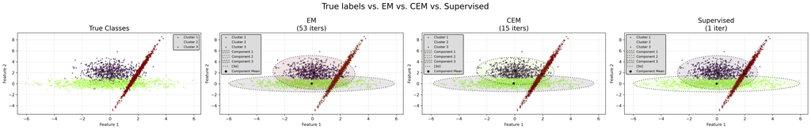

## Quantitative comparison

`adjusted_rand_score` and `purity_score` are permutation-invariant (they don't need the Hungarian remap), so they're computed on the raw predictions; `classification_report` needs matching label spaces, so it uses the remapped EM/CEM predictions and the supervised model's raw predictions (already label-aligned).

```python
raw_pred_em = gmm_em.predict(X_tensor)
raw_pred_cem = gmm_cem.predict(X_tensor)

results = {
    'EM': (raw_pred_em, pred_em),
    'CEM': (raw_pred_cem, pred_cem),
    'Supervised': (pred_sup, pred_sup),
}

print(f"{'Model':<12} {'ARI':>8} {'Purity':>8} {'Mean log-lik':>14} {'Iters':>7}")
for name, (raw_pred, aligned_pred) in results.items():
    ari = ClusteringMetrics.adjusted_rand_score(y_tensor, raw_pred)
    purity = ClusteringMetrics.purity_score(y_tensor, raw_pred)
    model = {'EM': gmm_em, 'CEM': gmm_cem, 'Supervised': gmm_sup}[name]
    print(f"{name:<12} {ari:8.4f} {purity:8.4f} {model.score(X_tensor):14.4f} {model.n_iter_:7d}")

for name, (raw_pred, aligned_pred) in results.items():
    print(f"\nPer-class report (precision / recall / f1), {name} model:")
    report = ClusteringMetrics.classification_report(y_tensor, aligned_pred)
    for label, metrics in sorted(report.items()):
        print(f"  class {label}: precision={metrics['precision']:.3f} recall={metrics['recall']:.3f} f1={metrics['f1-score']:.3f} support={metrics['support']}")
```

```
Model             ARI   Purity   Mean log-lik   Iters
EM             0.8055   0.9289        -3.0506      53
CEM            0.7991   0.9261        -3.0587      15
Supervised     0.8053   0.9289        -3.0517       1

Per-class report (precision / recall / f1), EM model:
  class 0: precision=0.954 recall=0.856 f1=0.903 support=800
  class 1: precision=0.896 recall=0.927 f1=0.911 support=1000
  class 2: precision=0.945 recall=0.989 f1=0.966 support=1000

Per-class report (precision / recall / f1), CEM model:
  class 0: precision=0.982 recall=0.820 f1=0.894 support=800
  class 1: precision=0.875 recall=0.948 f1=0.910 support=1000
  class 2: precision=0.943 recall=0.989 f1=0.965 support=1000

Per-class report (precision / recall / f1), Supervised model:
  class 0: precision=0.948 recall=0.863 f1=0.903 support=800
  class 1: precision=0.900 recall=0.922 f1=0.911 support=1000
  class 2: precision=0.944 recall=0.989 f1=0.966 support=1000
```

## Takeaways

- **Supervised fitting converges in exactly 1 iteration**, regardless of how much the classes overlap — because the assignment is fixed by the labels rather than estimated, `fit` is doing a single closed-form per-class MLE (see the design doc for why this is mathematically the fixed point of CEM with a label-driven C-step, not an approximation of it).
- **EM and CEM need the labels remapped** to compare against ground truth (arbitrary cluster indexing); the supervised fit doesn't, since `classes_` ties each component directly to its original label.
- **EM, CEM, and supervised fitting maximize different objectives, so their mean log-likelihoods aren't directly comparable as an accuracy measure.** EM directly maximizes the mixture's marginal log-likelihood — that *is* its objective, and it's free to place components wherever improves that number, including compensating for a few "wrong" points by shifting a boundary. Supervised fitting instead maximizes the *classification* log-likelihood on the true partition — a different, generally lower-or-equal quantity — so on this data EM's mean log-likelihood (-3.0506) ends up equal to or very slightly *better* than supervised's (-3.0517), even though supervised uses the correct partition rather than an estimated one. That's not a contradiction; it's a reminder that "better mean log-likelihood" isn't the same as "more correct clustering" (see the ARI/purity/per-class numbers above for that). CEM lands a bit further behind (-3.0587): unlike supervised fitting, its hard assignment is *estimated* via `argmax(resp)` each iteration, and that estimated partition costs it relative to fitting directly from the true one — but the size of that log-likelihood gap isn't a count of how many points CEM got wrong.